# Visualize Elife_RepSet_C60 tree

**Objective**

Notebook used to visualize tree for publication, highlighting the new MAGs (separate colors for archaea versus bacteria).

**For tutorial purposes, this notebook also includes some random bash and python code chunks**

## Requirements

**R libs**:

For details, see system info at the bottom of this report.

- knitr (not essential)
- tidytree
- ape
- phytools
- ggtree
- ggplot2
- tidyr

## Setup notebook

```r
library(tidytree)
library("ggplot2")
library(ape)
library("ggtree")
library(tidyverse)
library(phangorn)  #for midpoint rooting
```

```bash
#check the absolute path for our working directory
pwd
```

```
/mnt/c/Users/ndmic/WorkingDir/Writing_Presentations/Presentations_Workshops/NIOZ/2023/ProjectOrga_tutorial/1_Phylogenies/1_Undin_markers/code
```

## Load data

```r
#tree
tree_original  <-read.tree("../treefiles/Elife_25_BacArcBSRep_v1_no_gappy_seq.faa.treefile_renamed")
```

## Make a mapping file based on the tip labels

```r
#get the tip labels and print
labels <- as.data.frame(tree_original$tip.label)
#write.table(labels, "Figure///tree_labels.txt",  sep = "\t", row.names = F, quote =F)

#relabel column name
colnames(labels) <- "label"

#control that the count is what we expect
dim(labels)
```

```
[1] 2095    1
```

```r
#add a column were the rows go from 1 - xx to be able to always restore the tree order
mapping <- tibble::rownames_to_column(labels, "tree_order")

#create a new column, with NIOZ MAGs highlighted
mapping$category <- ifelse(grepl("NIOZ",mapping$label),'BS_MAG','Ref')

#split the label string to get the different tax levels
mapping <- separate(data = mapping, col = label, into = c("Domain", "Phylum", "Class", "Order", "Family", "Genus", "Species", "accession"), sep = "\\-", remove = FALSE)

#make a second category were we distinguish between arc and bac
mapping$category_2 <- ifelse((mapping$category == "BS_MAG" & mapping$Domain == "Archaea"  ),'BS_Arc',
                      ifelse((mapping$category == "BS_MAG" & mapping$Domain == "Bacteria"  ), "BS_Bac",
                      ifelse((mapping$category == "Ref" & mapping$Domain == "d__Archaea"  ), "Ref_Arc",
                      ifelse((mapping$category == "Ref" & mapping$Domain == "d__Bacteria"  ), "Ref_Bac",
                             'Ref'))))

#print final mapping file and control dimensions
head(mapping)
```

|  | tree_order | label | Domain | Phylum | Class | Order | Family | Genus | Species | accession | category | category_2 |
| --- | --- | --- | --- | --- | --- | --- | --- | --- | --- | --- | --- | --- |
| 1 | 1 | d__Archaea-p__Thermoproteota-c__Nitrososphaeria-o__Geothermarchaeales-f__JDFR_13-g__B109_G9-s__B109_G9_sp003661505-B21_G17 | d__Archaea | p__Thermoproteota | c__Nitrososphaeria | o__Geothermarchaeales | f__JDFR_13 | g__B109_G9 | s__B109_G9_sp003661505 | B21_G17 | Ref | Ref_Arc |
| 2 | 2 | d__Archaea-p__Hydrothermarchaeota-c__Hydrothermarchaeia-o__Hydrothermarchaeales-f__-g__-s__-B51_G15 | d__Archaea | p__Hydrothermarchaeota | c__Hydrothermarchaeia | o__Hydrothermarchaeales | f__ | g__ | s__ | B51_G15 | Ref | Ref_Arc |
| 3 | 3 | d__Archaea-p__Hydrothermarchaeota-c__Hydrothermarchaeia-o__Hydrothermarchaeales-f__Hydrothermarchaeaceae-g__Hydrothermarchaeum-s__Hydrothermarchaeum_profundi-GCA_002011125 | d__Archaea | p__Hydrothermarchaeota | c__Hydrothermarchaeia | o__Hydrothermarchaeales | f__Hydrothermarchaeaceae | g__Hydrothermarchaeum | s__Hydrothermarchaeum_profundi | GCA_002011125 | Ref | Ref_Arc |
| 4 | 4 | d__Archaea-p__Hydrothermarchaeota-c__Hydrothermarchaeia-o__Hydrothermarchaeales-f__BMS3B-g__BMS3B-s__BMS3B_sp002897955-GCA_002897955 | d__Archaea | p__Hydrothermarchaeota | c__Hydrothermarchaeia | o__Hydrothermarchaeales | f__BMS3B | g__BMS3B | s__BMS3B_sp002897955 | GCA_002897955 | Ref | Ref_Arc |
| 5 | 5 | d__Archaea-p__Hydrothermarchaeota-c__Hydrothermarchaeia-o__Hydrothermarchaeales-f__SZUA_236-g__J060-s__J060_sp003695745-GCA_003695745 | d__Archaea | p__Hydrothermarchaeota | c__Hydrothermarchaeia | o__Hydrothermarchaeales | f__SZUA_236 | g__J060 | s__J060_sp003695745 | GCA_003695745 | Ref | Ref_Arc |
| 6 | 6 | d__Archaea-p__Methanobacteriota-c__Methanobacteria-o__Methanobacteriales-f__Methanobacteriaceae-g__Methanosphaera-s__Methanosphaera_stadtmanae-GCA_000012545 | d__Archaea | p__Methanobacteriota | c__Methanobacteria | o__Methanobacteriales | f__Methanobacteriaceae | g__Methanosphaera | s__Methanosphaera_stadtmanae | GCA_000012545 | Ref | Ref_Arc |

```r
dim(mapping)
```

```
[1] 2095   12
```

## Cluster data and add info to tree

We define clusters based on how we want to color taxa in the tree. I.e. we want to give new MAGs from the archaea and bacteria different colors than for the reference genomes.

**Warning**

Carefully inspect if all sub-lists are populated and later check of the coloring of the branches is what you expect.

```r
#define clusters
my_list <- list(BS_Arc=subset(mapping, category_2 == "BS_Arc")$label,
            BS_Bac=subset(mapping, category_2 == "BS_Bac")$label ,
            Ref_Arc=subset(mapping, category_2 == "Ref_Arc")$label ,
            Ref_Bac=subset(mapping, category_2 == "Ref_Bac")$label
            )

str(my_list)
```

```
List of 4
 $ BS_Arc : chr [1:110] "Archaea-Euryarchaeota-Halobacteriota-Syntropharchaeia-ANME_1-ANME_1-WJOV01-none-NIOZ115_mb_b162_2-rep" "Archaea-Euryarchaeota-Halobacteriota-Syntropharchaeia-ANME_1-ANME_1-WJOV01-none-NIOZ125_mb_b204_2-rep" "Archaea-Euryarchaeota-Thermoplasmatota-Thermoplasmata-none-none-non…
 $ BS_Bac : chr [1:407] "Bacteria-Bacteria-Proteobacteria-Gammaproteobacteria-Enterobacterales-Alteromonadaceae-Alteromonas-none-NIOZ130_cc_b15_2-rep" "Bacteria-Bacteria-Proteobacteria-Gammaproteobacteria-Pseudomonadales-Halieaceae-Luminiphilus-Luminiphilus_sp003"| __truncated__ "Bacteria-Bacteria-P…
 $ Ref_Arc: chr [1:423] "d__Archaea-p__Thermoproteota-c__Nitrososphaeria-o__Geothermarchaeales-f__JDFR_13-g__B109_G9-s__B109_G9_sp003661505-B21_G17" "d__Archaea-p__Hydrothermarchaeota-c__Hydrothermarchaeia-o__Hydrothermarchaeales-f__-g__-s__-B51_G15" "d__Archaea-p__Hydrothermarchaeota-c__Hydrotherma…
 $ Ref_Bac: chr [1:1155] "d__Bacteria-p__Proteobacteria-c__Gammaproteobacteria-o__Enterobacterales-f__Enterobacteriaceae-g__Escherichia-s"| __truncated__ "d__Bacteria-p__Proteobacteria-c__Gammaproteobacteria-o__Enterobacterales-f__Enterobacteriaceae-g__Hafnia-s__Haf"| __truncated__ "d__Bacteria-p__P…
```

```r
#add clusters to our raw tree
tree_original_grouped <- groupOTU(tree_original, my_list, overlap='abandon', connect = FALSE)
```

## Pre-view tree to get the node lables

Notice: Disable scale_color_manual if you have more than 3 levels or manually change

```r
# 0 --> darkgrey
# BS_Arc --> #a557b3 (darkpurple)
# BS_Bac  --> #004c6d (darkblue)
# Ref_Arc --> #ffa7ff (lightpurple)
# Ref_Bac --> #00a1c1 (lightblue)

tree_1 <-
ggtree(tree_original_grouped, layout="roundrect", size = 0.1, aes(color = group)) +
  geom_treescale() +
  scale_color_manual(values=c("darkgrey", "#a557b3", "#004c6d", "darkgrey","darkgrey" )) +
  geom_tiplab(size = 1, color = "black") +
  geom_text2(aes(x=branch, label=node), size = 1, vjust=0)


pdf("../figures//tree_long_nodes.pdf", width=30, height=150)
tree_1
dev.off()
```

## Pre-view tree to get the bootstraps labels

```r
tree_1 <-
ggtree(tree_original_grouped, layout="roundrect", size = 0.1, aes(color = group)) +
  geom_treescale() +
  scale_color_manual(values=c("darkgrey", "#a557b3", "#004c6d", "darkgrey","darkgrey" )) +
  geom_tiplab(size = 0.8, color = "black") +
  geom_text2(aes(subset = !isTip, label=label), size = 0.6, vjust=0, hjust = 1)

pdf("../figures/tree_long_BS.pdf", width=30, height=150)
tree_1
dev.off()
```

After visual inspection:

- If we want to root with DPANN that is node –> 684
- If we want to root between arc and bac, that is node –> 2104

## Clean tree

### Root tree and add metadata

```r
#root (use ape to root with DPANN, use phangorn for midpoint rooting)
#tree_DPANN_root <- ape::root(tree_ape, node = 684, edgelabel = TRUE)
tree_midpoint<- phangorn::midpoint(tree_original, node.labels = "support")

#add mapping data
tree_mapped <- tidytree::full_join(tree_midpoint, mapping, by='label')

#control structure in tree file
str(tree_mapped)
```

```
Formal class 'treedata' [package "tidytree"] with 11 slots
  ..@ file       : chr(0)
  ..@ treetext   : chr(0)
  ..@ phylo      :List of 5
  .. ..$ edge       : int [1:4188, 1:2] 2097 2112 2112 2111 2110 2116 2116 2115 2114 2113 ...
  .. .. ..- attr(*, "dimnames")=List of 2
  .. .. .. ..$ : NULL
  .. .. .. ..$ : chr [1:2] "parent" "node"
  .. ..$ edge.length: num [1:4188] 0.25 0.193 0.132 0.245 0.262 ...
  .. ..$ tip.label  : chr [1:2095] "d__Archaea-p__Thermoproteota-c__Nitrososphaeria-o__Geothermarchaeales-f__JDFR_13-g__B109_G9-s__B109_G9_sp003661505-B21_G17" "d__Archaea-p__Hydrothermarchaeota-c__Hydrothermarchaeia-o__Hydrothermarchaeales-f__-g__-s__-B51_G15" "d__Archaea-p__Hydrothermarchaeota-c__…
  .. ..$ node.label : chr [1:2094] "" "100/100" "99.7/100" "99.3/99" ...
  .. ..$ Nnode      : int 2094
  .. ..- attr(*, "class")= chr "phylo"
  ..@ data       : tibble [4,189 × 12] (S3: tbl_df/tbl/data.frame)
  .. ..$ node      : int [1:4189] 1 2 3 4 5 6 7 8 9 10 ...
  .. ..$ tree_order: chr [1:4189] "1" "2" "3" "4" ...
  .. ..$ Domain    : chr [1:4189] "d__Archaea" "d__Archaea" "d__Archaea" "d__Archaea" ...
  .. ..$ Phylum    : chr [1:4189] "p__Thermoproteota" "p__Hydrothermarchaeota" "p__Hydrothermarchaeota" "p__Hydrothermarchaeota" ...
  .. ..$ Class     : chr [1:4189] "c__Nitrososphaeria" "c__Hydrothermarchaeia" "c__Hydrothermarchaeia" "c__Hydrothermarchaeia" ...
  .. ..$ Order     : chr [1:4189] "o__Geothermarchaeales" "o__Hydrothermarchaeales" "o__Hydrothermarchaeales" "o__Hydrothermarchaeales" ...
  .. ..$ Family    : chr [1:4189] "f__JDFR_13" "f__" "f__Hydrothermarchaeaceae" "f__BMS3B" ...
  .. ..$ Genus     : chr [1:4189] "g__B109_G9" "g__" "g__Hydrothermarchaeum" "g__BMS3B" ...
  .. ..$ Species   : chr [1:4189] "s__B109_G9_sp003661505" "s__" "s__Hydrothermarchaeum_profundi" "s__BMS3B_sp002897955" ...
  .. ..$ accession : chr [1:4189] "B21_G17" "B51_G15" "GCA_002011125" "GCA_002897955" ...
  .. ..$ category  : chr [1:4189] "Ref" "Ref" "Ref" "Ref" ...
  .. ..$ category_2: chr [1:4189] "Ref_Arc" "Ref_Arc" "Ref_Arc" "Ref_Arc" ...
  ..@ extraInfo  : tibble [0 × 0] (S3: tbl_df/tbl/data.frame)
 Named list()
  ..@ tip_seq    : NULL
  ..@ anc_seq    : NULL
  ..@ seq_type   : chr(0)
  ..@ tipseq_file: chr(0)
  ..@ ancseq_file: chr(0)
  ..@ info       : list()
```

```r
#define groups for mapped tree
tree_mapped_grouped <- groupOTU(tree_mapped, my_list, overlap='abandon', connect = FALSE)
```

### Deal with double boostrap

```r
#convert our tree into a data table
q <- ggtree(tree_mapped_grouped)
d <- q$data

#view structure
head(as.data.frame(d))
```

|  | parent | node | branch.length | label | group | tree_order | Domain | Phylum | Class | Order | Family | Genus | Species | accession | category | category_2 | isTip | x | y | branch | angle |
| --- | --- | --- | --- | --- | --- | --- | --- | --- | --- | --- | --- | --- | --- | --- | --- | --- | --- | --- | --- | --- | --- |
| 1 | 2097 | 1 | 0.2504193 | d__Archaea-p__Thermoproteota-c__Nitrososphaeria-o__Geothermarchaeales-f__JDFR_13-g__B109_G9-s__B109_G9_sp003661505-B21_G17 | Ref_Arc | 1 | d__Archaea | p__Thermoproteota | c__Nitrososphaeria | o__Geothermarchaeales | f__JDFR_13 | g__B109_G9 | s__B109_G9_sp003661505 | B21_G17 | Ref | Ref_Arc | TRUE | 2.284362 | 329 | 2.159153 | 56.53461 |
| 2 | 2112 | 2 | 0.1931798 | d__Archaea-p__Hydrothermarchaeota-c__Hydrothermarchaeia-o__Hydrothermarchaeales-f__-g__-s__-B51_G15 | Ref_Arc | 2 | d__Archaea | p__Hydrothermarchaeota | c__Hydrothermarchaeia | o__Hydrothermarchaeales | f__ | g__ | s__ | B51_G15 | Ref | Ref_Arc | TRUE | 1.779809 | 397 | 1.683219 | 68.21957 |
| 3 | 2112 | 3 | 0.1316818 | d__Archaea-p__Hydrothermarchaeota-c__Hydrothermarchaeia-o__Hydrothermarchaeales-f__Hydrothermarchaeaceae-g__Hydrothermarchaeum-s__Hydrothermarchaeum_profundi-GCA_002011125 | Ref_Arc | 3 | d__Archaea | p__Hydrothermarchaeota | c__Hydrothermarchaeia | o__Hydrothermarchaeales | f__Hydrothermarchaeaceae | g__Hydrothermarchaeum | s__Hydrothermarchaeum_profundi | GCA_002011125 | Ref | Ref_Arc | TRUE | 1.718311 | 398 | 1.652470 | 68.39141 |
| 4 | 2111 | 4 | 0.2446354 | d__Archaea-p__Hydrothermarchaeota-c__Hydrothermarchaeia-o__Hydrothermarchaeales-f__BMS3B-g__BMS3B-s__BMS3B_sp002897955-GCA_002897955 | Ref_Arc | 4 | d__Archaea | p__Hydrothermarchaeota | c__Hydrothermarchaeia | o__Hydrothermarchaeales | f__BMS3B | g__BMS3B | s__BMS3B_sp002897955 | GCA_002897955 | Ref | Ref_Arc | TRUE | 1.765892 | 396 | 1.643574 | 68.04773 |
| 5 | 2110 | 5 | 0.2621935 | d__Archaea-p__Hydrothermarchaeota-c__Hydrothermarchaeia-o__Hydrothermarchaeales-f__SZUA_236-g__J060-s__J060_sp003695745-GCA_003695745 | Ref_Arc | 5 | d__Archaea | p__Hydrothermarchaeota | c__Hydrothermarchaeia | o__Hydrothermarchaeales | f__SZUA_236 | g__J060 | s__J060_sp003695745 | GCA_003695745 | Ref | Ref_Arc | TRUE | 1.746577 | 395 | 1.615480 | 67.87589 |
| 6 | 2116 | 6 | 0.1699508 | d__Archaea-p__Methanobacteriota-c__Methanobacteria-o__Methanobacteriales-f__Methanobacteriaceae-g__Methanosphaera-s__Methanosphaera_stadtmanae-GCA_000012545 | Ref_Arc | 6 | d__Archaea | p__Methanobacteriota | c__Methanobacteria | o__Methanobacteriales | f__Methanobacteriaceae | g__Methanosphaera | s__Methanosphaera_stadtmanae | GCA_000012545 | Ref | Ref_Arc | TRUE | 1.856369 | 402 | 1.771394 | 69.07876 |

```r
#remove irrelevant tip data
#d <- d[!d$isTip,]
head(as.data.frame(d))
```

|  | parent | node | branch.length | label | group | tree_order | Domain | Phylum | Class | Order | Family | Genus | Species | accession | category | category_2 | isTip | x | y | branch | angle |
| --- | --- | --- | --- | --- | --- | --- | --- | --- | --- | --- | --- | --- | --- | --- | --- | --- | --- | --- | --- | --- | --- |
| 1 | 2097 | 1 | 0.2504193 | d__Archaea-p__Thermoproteota-c__Nitrososphaeria-o__Geothermarchaeales-f__JDFR_13-g__B109_G9-s__B109_G9_sp003661505-B21_G17 | Ref_Arc | 1 | d__Archaea | p__Thermoproteota | c__Nitrososphaeria | o__Geothermarchaeales | f__JDFR_13 | g__B109_G9 | s__B109_G9_sp003661505 | B21_G17 | Ref | Ref_Arc | TRUE | 2.284362 | 329 | 2.159153 | 56.53461 |
| 2 | 2112 | 2 | 0.1931798 | d__Archaea-p__Hydrothermarchaeota-c__Hydrothermarchaeia-o__Hydrothermarchaeales-f__-g__-s__-B51_G15 | Ref_Arc | 2 | d__Archaea | p__Hydrothermarchaeota | c__Hydrothermarchaeia | o__Hydrothermarchaeales | f__ | g__ | s__ | B51_G15 | Ref | Ref_Arc | TRUE | 1.779809 | 397 | 1.683219 | 68.21957 |
| 3 | 2112 | 3 | 0.1316818 | d__Archaea-p__Hydrothermarchaeota-c__Hydrothermarchaeia-o__Hydrothermarchaeales-f__Hydrothermarchaeaceae-g__Hydrothermarchaeum-s__Hydrothermarchaeum_profundi-GCA_002011125 | Ref_Arc | 3 | d__Archaea | p__Hydrothermarchaeota | c__Hydrothermarchaeia | o__Hydrothermarchaeales | f__Hydrothermarchaeaceae | g__Hydrothermarchaeum | s__Hydrothermarchaeum_profundi | GCA_002011125 | Ref | Ref_Arc | TRUE | 1.718311 | 398 | 1.652470 | 68.39141 |
| 4 | 2111 | 4 | 0.2446354 | d__Archaea-p__Hydrothermarchaeota-c__Hydrothermarchaeia-o__Hydrothermarchaeales-f__BMS3B-g__BMS3B-s__BMS3B_sp002897955-GCA_002897955 | Ref_Arc | 4 | d__Archaea | p__Hydrothermarchaeota | c__Hydrothermarchaeia | o__Hydrothermarchaeales | f__BMS3B | g__BMS3B | s__BMS3B_sp002897955 | GCA_002897955 | Ref | Ref_Arc | TRUE | 1.765892 | 396 | 1.643574 | 68.04773 |
| 5 | 2110 | 5 | 0.2621935 | d__Archaea-p__Hydrothermarchaeota-c__Hydrothermarchaeia-o__Hydrothermarchaeales-f__SZUA_236-g__J060-s__J060_sp003695745-GCA_003695745 | Ref_Arc | 5 | d__Archaea | p__Hydrothermarchaeota | c__Hydrothermarchaeia | o__Hydrothermarchaeales | f__SZUA_236 | g__J060 | s__J060_sp003695745 | GCA_003695745 | Ref | Ref_Arc | TRUE | 1.746577 | 395 | 1.615480 | 67.87589 |
| 6 | 2116 | 6 | 0.1699508 | d__Archaea-p__Methanobacteriota-c__Methanobacteria-o__Methanobacteriales-f__Methanobacteriaceae-g__Methanosphaera-s__Methanosphaera_stadtmanae-GCA_000012545 | Ref_Arc | 6 | d__Archaea | p__Methanobacteriota | c__Methanobacteria | o__Methanobacteriales | f__Methanobacteriaceae | g__Methanosphaera | s__Methanosphaera_stadtmanae | GCA_000012545 | Ref | Ref_Arc | TRUE | 1.856369 | 402 | 1.771394 | 69.07876 |

```r
#split the two bs
d_cleaned <- separate(data = d, col = label, into = c("alrt", "bb"), sep = "/", remove = F)

#clean labels and make numeric
d_cleaned$bb <- as.numeric(d_cleaned$bb)
d_cleaned$alrt <- as.numeric(d_cleaned$alrt)

#set cutoffs to use for alrt
d_cleaned$alrt_cats <- d_cleaned$alrt
d_cleaned$alrt_cats <- ifelse(d_cleaned$alrt_cats == 100, 100,
                        ifelse(d_cleaned$alrt_cats >= 90, 90,
                        ifelse(d_cleaned$alrt_cats >=80, 80
                              , 0)))

#convert to char
d_cleaned$alrt_cats <- as.character(d_cleaned$alrt_cats)

#control
head(as.data.frame(d_cleaned))
```

|  | parent | node | branch.length | label | alrt | bb | group | tree_order | Domain | Phylum | Class | Order | Family | Genus | Species | accession | category | category_2 | isTip | x | y | branch | angle | alrt_cats |
| --- | --- | --- | --- | --- | --- | --- | --- | --- | --- | --- | --- | --- | --- | --- | --- | --- | --- | --- | --- | --- | --- | --- | --- | --- |
| 1 | 2097 | 1 | 0.2504193 | d__Archaea-p__Thermoproteota-c__Nitrososphaeria-o__Geothermarchaeales-f__JDFR_13-g__B109_G9-s__B109_G9_sp003661505-B21_G17 | NA | NA | Ref_Arc | 1 | d__Archaea | p__Thermoproteota | c__Nitrososphaeria | o__Geothermarchaeales | f__JDFR_13 | g__B109_G9 | s__B109_G9_sp003661505 | B21_G17 | Ref | Ref_Arc | TRUE | 2.284362 | 329 | 2.159153 | 56.53461 | NA |
| 2 | 2112 | 2 | 0.1931798 | d__Archaea-p__Hydrothermarchaeota-c__Hydrothermarchaeia-o__Hydrothermarchaeales-f__-g__-s__-B51_G15 | NA | NA | Ref_Arc | 2 | d__Archaea | p__Hydrothermarchaeota | c__Hydrothermarchaeia | o__Hydrothermarchaeales | f__ | g__ | s__ | B51_G15 | Ref | Ref_Arc | TRUE | 1.779809 | 397 | 1.683219 | 68.21957 | NA |
| 3 | 2112 | 3 | 0.1316818 | d__Archaea-p__Hydrothermarchaeota-c__Hydrothermarchaeia-o__Hydrothermarchaeales-f__Hydrothermarchaeaceae-g__Hydrothermarchaeum-s__Hydrothermarchaeum_profundi-GCA_002011125 | NA | NA | Ref_Arc | 3 | d__Archaea | p__Hydrothermarchaeota | c__Hydrothermarchaeia | o__Hydrothermarchaeales | f__Hydrothermarchaeaceae | g__Hydrothermarchaeum | s__Hydrothermarchaeum_profundi | GCA_002011125 | Ref | Ref_Arc | TRUE | 1.718311 | 398 | 1.652470 | 68.39141 | NA |
| 4 | 2111 | 4 | 0.2446354 | d__Archaea-p__Hydrothermarchaeota-c__Hydrothermarchaeia-o__Hydrothermarchaeales-f__BMS3B-g__BMS3B-s__BMS3B_sp002897955-GCA_002897955 | NA | NA | Ref_Arc | 4 | d__Archaea | p__Hydrothermarchaeota | c__Hydrothermarchaeia | o__Hydrothermarchaeales | f__BMS3B | g__BMS3B | s__BMS3B_sp002897955 | GCA_002897955 | Ref | Ref_Arc | TRUE | 1.765892 | 396 | 1.643574 | 68.04773 | NA |
| 5 | 2110 | 5 | 0.2621935 | d__Archaea-p__Hydrothermarchaeota-c__Hydrothermarchaeia-o__Hydrothermarchaeales-f__SZUA_236-g__J060-s__J060_sp003695745-GCA_003695745 | NA | NA | Ref_Arc | 5 | d__Archaea | p__Hydrothermarchaeota | c__Hydrothermarchaeia | o__Hydrothermarchaeales | f__SZUA_236 | g__J060 | s__J060_sp003695745 | GCA_003695745 | Ref | Ref_Arc | TRUE | 1.746577 | 395 | 1.615480 | 67.87589 | NA |
| 6 | 2116 | 6 | 0.1699508 | d__Archaea-p__Methanobacteriota-c__Methanobacteria-o__Methanobacteriales-f__Methanobacteriaceae-g__Methanosphaera-s__Methanosphaera_stadtmanae-GCA_000012545 | NA | NA | Ref_Arc | 6 | d__Archaea | p__Methanobacteriota | c__Methanobacteria | o__Methanobacteriales | f__Methanobacteriaceae | g__Methanosphaera | s__Methanosphaera_stadtmanae | GCA_000012545 | Ref | Ref_Arc | TRUE | 1.856369 | 402 | 1.771394 | 69.07876 | NA |

## Plot tree

### Long and rooted, show bootstrap support

```r
tree_1 <-
ggtree(tree_mapped_grouped, layout="roundrect", size = 0.001, aes(color = group)) +
  geom_treescale() +
  scale_color_manual("" , values=c("darkgrey", "#a557b3", "#004c6d", "darkgrey","darkgrey" ),
                     label = c("basal branch", "archaeal BS MAG", "bacterial BS MAG", "archaeal reference genome", "bacterial reference genome")) +
  geom_tiplab(size = 0.8, aes(color = group)) +
  geom_text2(aes(subset = !isTip, label=label), size = 0.4, vjust=0, hjust = 1) +
  theme(legend.position="top") +
  xlim(NA, 15) +
  theme(plot.margin = unit(c(14,8,14,8), "mm"))

pdf("../figures/tree_long_midpoint_BS_r202.pdf", width=15, height=100)
tree_1
dev.off()
```

### Long and rooted, showing node label

```r
tree_2 <-
ggtree(tree_mapped_grouped, layout="roundrect", size = 0.05, aes(color = group)) +
  geom_treescale() +
  scale_color_manual(values=c("darkgrey", "#a557b3", "#004c6d", "darkgrey","darkgrey" )) +
  geom_tiplab(size = 1, color = "black") +
  geom_text2(aes(x=branch, label=node), size = 1.5, vjust=0) +
  coord_cartesian(clip = 'off')

#tree_long

pdf("../figures/tree_long_rooted_Node.pdf", width=20, height=80)
tree_2
dev.off()
```

### Circular and color the mags of interest circle BS

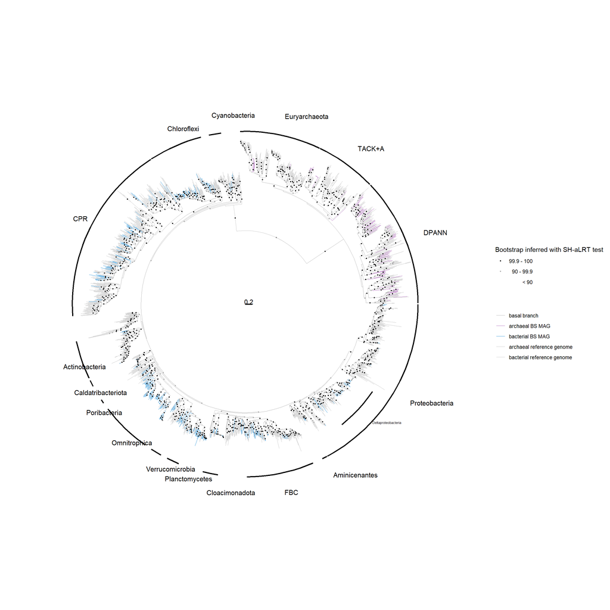

Figure 1: Species tree using the Elife marker and run using the C60 model

```r
#plot
tree_test <-
ggtree(tree_mapped_grouped, size = 0.3, layout='circular', aes(color=group)) +   #, branch.length='none'
  xlim(-2, NA) +
  geom_treescale(x= -2, y= 0, linesize = 1) +
  scale_color_manual(values=c("darkgrey", "#a557b3", "#0E86D4", "grey","grey"),
                    label = c("basal branch", "archaeal BS MAG", "bacterial BS MAG", "archaeal reference genome", "bacterial reference genome")) +
  guides(color=guide_legend("")) +

  #label lineages of interest, gives a warning, can be ignored
  geom_cladelabel(node=3010, label="Omnitrophica", angle=0, fontsize=4, offset=0, offset.text = 0.5, align = T, barsize = 1) +
  geom_cladelabel(node=2901, label="Verrucomicrobia", angle=0, fontsize=4, offset=0, offset.text = 0.5, align = T, barsize = 1) +
  geom_cladelabel(node=2938, label="Planctomycetes", angle=0, fontsize=4, offset=0, offset.text = 0.5, align = T, barsize = 1) +
  geom_cladelabel(node=2709, label="FBC", angle=0, fontsize=4, offset=0, offset.text = 0.5, align = T, barsize = 1) +
  geom_cladelabel(node=2280, label="Proteobacteria", angle=0, fontsize=4, offset=0, offset.text = 0.5, align = T, barsize = 1) +
  geom_cladelabel(node=2484, label="Deltaproteobacteria", angle=0, fontsize=2, offset=-0.5, offset.text = 0.5, align = T, barsize = 1) +
  geom_cladelabel(node=2647, label="Aminicenantes", angle=0, fontsize=4, offset=0, offset.text = 0.5, align = T, barsize = 1) +
  geom_cladelabel(node=3120, label="Poribacteria", angle=0, fontsize=4, offset=0, offset.text = 0.5, align = T, barsize = 1) +
  geom_cladelabel(node=2855, label="Cloacimonadota", angle=0, fontsize=4, offset=0, offset.text = 0.5, align = T, barsize = 1) +
  geom_cladelabel(node=3769, label="Cyanobacteria", angle=0, fontsize=4, offset=0, offset.text = 0.5, align = T, barsize = 1) +
  geom_cladelabel(node=3218, label="Actinobacteria", angle=0, fontsize=4, offset=0, offset.text = 0.5, align = T, barsize = 1) +
  geom_cladelabel(node=3404, label="CPR", angle=0, fontsize=4, offset=0, offset.text = 0.5, align = T, barsize = 1) +
  geom_cladelabel(node=3296, label="Chloroflexi", angle=0, fontsize=4, offset=0, offset.text = 0.5, align = T, barsize = 1) +
  geom_cladelabel(node=3157, label="Caldatribacteriota", angle=0, fontsize=4, offset=0, offset.text = 0.5, align = T, barsize = 1) +
  geom_cladelabel(node=3825, label="DPANN", angle=0, fontsize=4, offset=0, offset.text = 0.5, align = T, barsize = 1) +
  geom_cladelabel(node=2106, label="Euryarchaeota", angle=0, fontsize=4, offset=0, offset.text = 0.5, align = T, barsize = 1) +
  geom_cladelabel(node=2103, label="TACK+A", angle=0, fontsize=4, offset=0, offset.text = 0.5, align = T, barsize = 1) +
  #geom_cladelabel(node=4082, label="Asgard", angle=0, fontsize=4, offset=0, offset.text = 0.5, align = T, barsize = 1) +

  #add in dots for BS supports
  geom_nodepoint(data = d_cleaned,aes(fill = cut(as.numeric(alrt),c(0,90,99.9,100)), x =  branch),shape = 21, size = 0.5 , colour = "transparent") +
  scale_fill_manual(values = c("black","darkgrey", "transparent"),  name = "Bootstrap inferred with SH-aLRT test", breaks = c("(99.9,100]", "(90,99.9]", "(0,90]" ), labels = expression("99.9 - 100", "90 - 99.9", "< 90" ) )

#print
#pdf("../figures//circular_tree_grouped_2.pdf", width=20, height=20)
tree_test
#dev.off()
```

The treescale position in rectangular is: x co-ordinate is relative to the root in branchlength, and y co-ord is relative to the number of sequences

Additional options with:

- Color label and bar –> color = “#EC762F”

### Circular and color the mags of interest written BS (control)

```r
#set cutoff for bs
d_cutoff <- d_cleaned[d_cleaned$alrt > 90,]

#plot
tree_test <-
ggtree(tree_mapped_grouped, layout='circular', aes(color=group)) +   #, branch.length='none'
  xlim(-2, NA) +
  geom_treescale(x= -2, y= 0, linesize = 1) +
  scale_color_manual(values=c("darkgrey", "#a557b3", "#004c6d", "grey","grey" )) +
  guides(color=guide_legend("")) +
  geom_tiplab(size = 0.2, color = "lightgrey") +
  geom_text(data=d_cleaned, aes(label=alrt), size = 0.5, color = "black")
  #scale_size_manual(values=c(0,2,4,6))
  #scale_size_continuous(range = c(0, 1)) # scales point sizes
  #geom_text2(aes(subset = !isTip, label=label), size = 0.8)
  #geom_tippoint(aes(colour=color), size = 0.1)
  #geom_text(aes(label=node))

pdf("../figures/circular_tree2_written_bs.pdf", width=15, height=15)
tree_test
dev.off()
```

## Random py example code

```python
import matplotlib.pyplot as plt
import numpy as np

fig = plt.figure()
x = np.arange(10)
y = 2.5 * np.sin(x / 20 * np.pi)
yerr = np.linspace(0.05, 0.2, 10)

plt.errorbar(x, y + 3, yerr=yerr, label='both limits (default)')
```

```
<ErrorbarContainer object of 3 artists>
```

```python
plt.errorbar(x, y + 2, yerr=yerr, uplims=True, label='uplims=True')
```

```
<ErrorbarContainer object of 3 artists>
```

```python
plt.errorbar(x, y + 1, yerr=yerr, uplims=True, lolims=True,
             label='uplims=True, lolims=True')
```

```
<ErrorbarContainer object of 3 artists>
```

```python
upperlimits = [True, False] * 5
lowerlimits = [False, True] * 5
plt.errorbar(x, y, yerr=yerr, uplims=upperlimits, lolims=lowerlimits,
             label='subsets of uplims and lolims')
```

```
<ErrorbarContainer object of 3 artists>
```

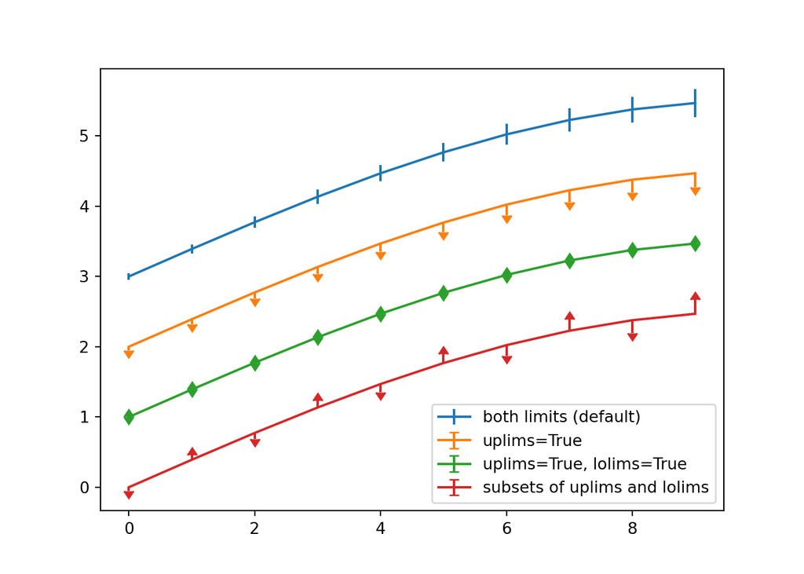

```python
plt.legend(loc='lower right')
plt.show(fig)
```